# Aula 3 - Introdução à biblioteca ggplot2

```r
#Apagar todos os objetos da memoria
rm(list=ls())
```

# O que são a gramática dos gráficos?

Brevemente, a gramática nos diz que um gráfico estatistico é um mapeamento a partir dos dados à atributos estéticos (cores, formas e tamanhos) de objetos geométricos (pontos, linhas, barras) (Wickham, 2009).

# Componentes

1. Os dados **(data)** que voce quer visualizar e o conjunto de mapeamentos estéticos que descrevem como as variáveis nos dados são mapeadas aos atributos estéticos que voce pode perceber.
2. Objetos geométricos **(geoms)** que representam o que voce na verdade ver nos graficos: pontos, linhas, poligonos, etc .
3. **(stats)** para resumir os dados em muitas maneiras. Por exemplo, contar observações para criar histogramas, **(stats)** é opcional mas muito util.
4. **(scales)** produz uma legenda ou eixo, o qual prove um mapeamento inverso para fazer possivel ler os dados originais atraves do grafico
5. Um sistema de coordenadas, **(coord)**, descreve como os dados são mapeados no plano de um grafico. Isto tambem prove eixos e linhas de grid para ser possivel ler no grafico. Normalmente, coordenadas cartesianas são utilizadas, mas um numero de outras estão disponiveis, incluindo coordenadas polares e projeções de mapa.
6. Facetas **(facet)** descreve como quebrar os dados em subconjuntos e como mostra-los em pequenos e multiplos graficos.

# Iniciando com a funcao qplot

## Uso basico

```r
#Carregar biblioteca ggplot2

library(ggplot2)

#Conjunto de dados  - Diamantes
data(diamonds)

#Imprimir as primeiras 6 linhas
head(diamonds)
```

```
## # A tibble: 6 x 10
##   carat cut       color clarity depth table price     x     y     z
##   <dbl> <ord>     <ord> <ord>   <dbl> <dbl> <int> <dbl> <dbl> <dbl>
## 1 0.230 Ideal     E     SI2      61.5  55.0   326  3.95  3.98  2.43
## 2 0.210 Premium   E     SI1      59.8  61.0   326  3.89  3.84  2.31
## 3 0.230 Good      E     VS1      56.9  65.0   327  4.05  4.07  2.31
## 4 0.290 Premium   I     VS2      62.4  58.0   334  4.20  4.23  2.63
## 5 0.310 Good      J     SI2      63.3  58.0   335  4.34  4.35  2.75
## 6 0.240 Very Good J     VVS2     62.8  57.0   336  3.94  3.96  2.48
```

```r
#Mostrar a estrutura do data.frame
str(diamonds)
```

```
## Classes 'tbl_df', 'tbl' and 'data.frame':    53940 obs. of  10 variables:
##  $ carat  : num  0.23 0.21 0.23 0.29 0.31 0.24 0.24 0.26 0.22 0.23 ...
##  $ cut    : Ord.factor w/ 5 levels "Fair"<"Good"<..: 5 4 2 4 2 3 3 3 1 3 ...
##  $ color  : Ord.factor w/ 7 levels "D"<"E"<"F"<"G"<..: 2 2 2 6 7 7 6 5 2 5 ...
##  $ clarity: Ord.factor w/ 8 levels "I1"<"SI2"<"SI1"<..: 2 3 5 4 2 6 7 3 4 5 ...
##  $ depth  : num  61.5 59.8 56.9 62.4 63.3 62.8 62.3 61.9 65.1 59.4 ...
##  $ table  : num  55 61 65 58 58 57 57 55 61 61 ...
##  $ price  : int  326 326 327 334 335 336 336 337 337 338 ...
##  $ x      : num  3.95 3.89 4.05 4.2 4.34 3.94 3.95 4.07 3.87 4 ...
##  $ y      : num  3.98 3.84 4.07 4.23 4.35 3.96 3.98 4.11 3.78 4.05 ...
##  $ z      : num  2.43 2.31 2.31 2.63 2.75 2.48 2.47 2.53 2.49 2.39 ...
```

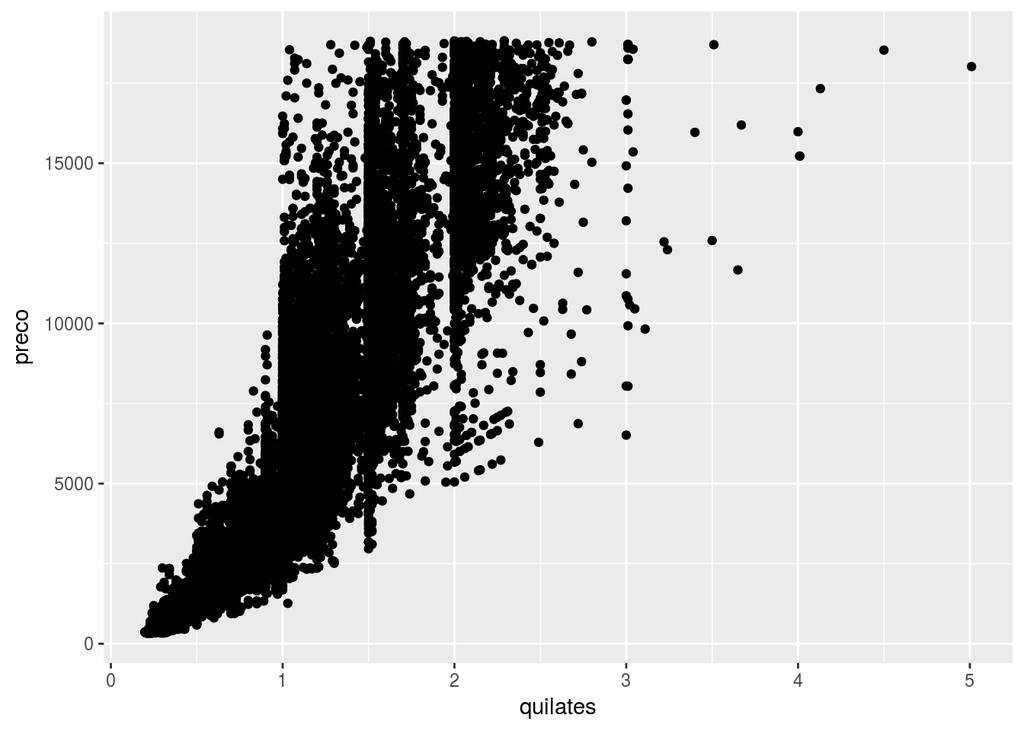

```r
#Grafico de dispersao quilates versus preco
qplot(carat, price, data = diamonds, xlab="quilates",
      ylab="preco")
```

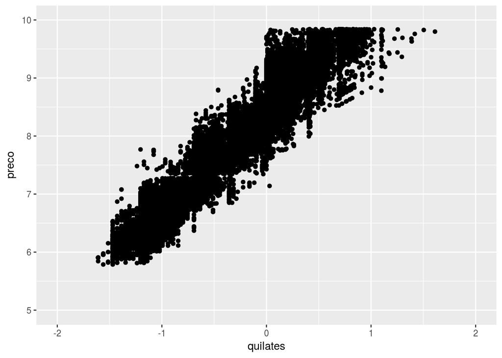

```r
#Grafico de dispersao quilates versus preco em escala
#logaritmica para os dois eixos


qplot(log(carat), log(price), data = diamonds, xlab="quilates", ylab="preco", xlim=c(-2,2), ylim=c(5,10))
```

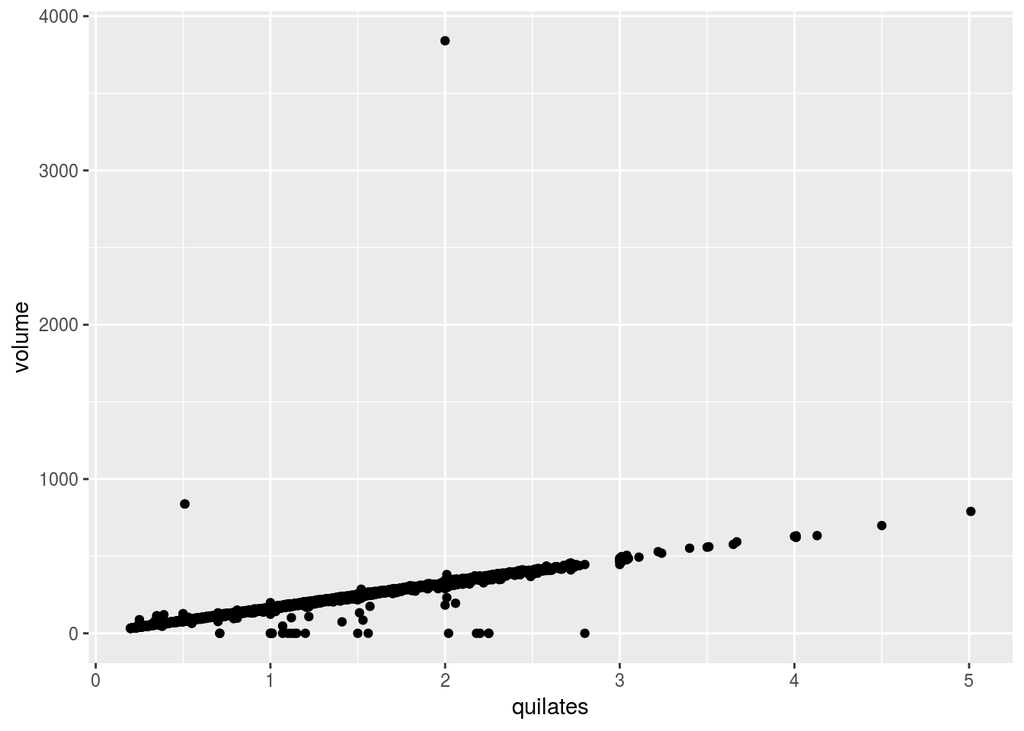

```r
#Grafico de dispersao quilates versus volume (x * y * z)

qplot(carat, x*y*z, data = diamonds, xlab="quilates", ylab="volume" )
```

## Usando atributos estéticos: cores, formas e tamanhos

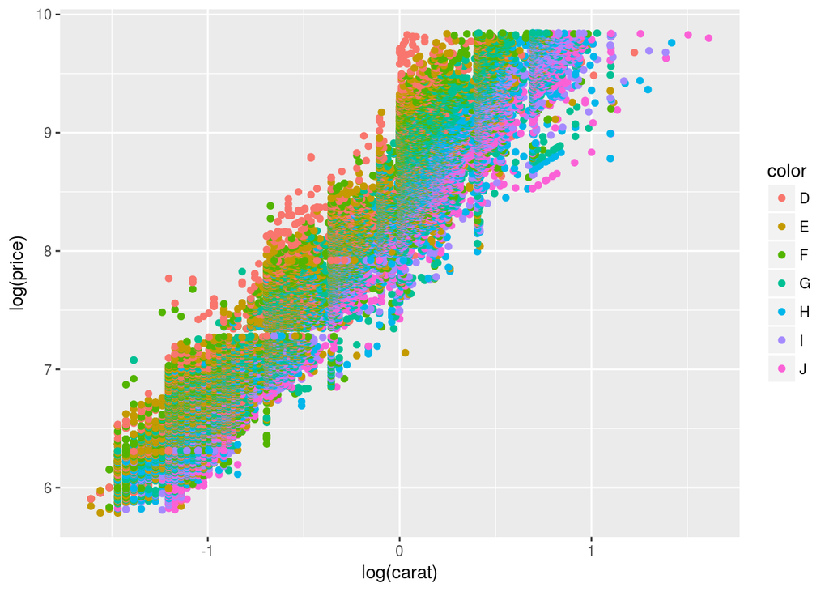

```r
#Grafico de dispersao quilates versus preco
#com cores diferentes para cada cor de diamante
qplot(log(carat), log(price), data = diamonds, colour = color)
```

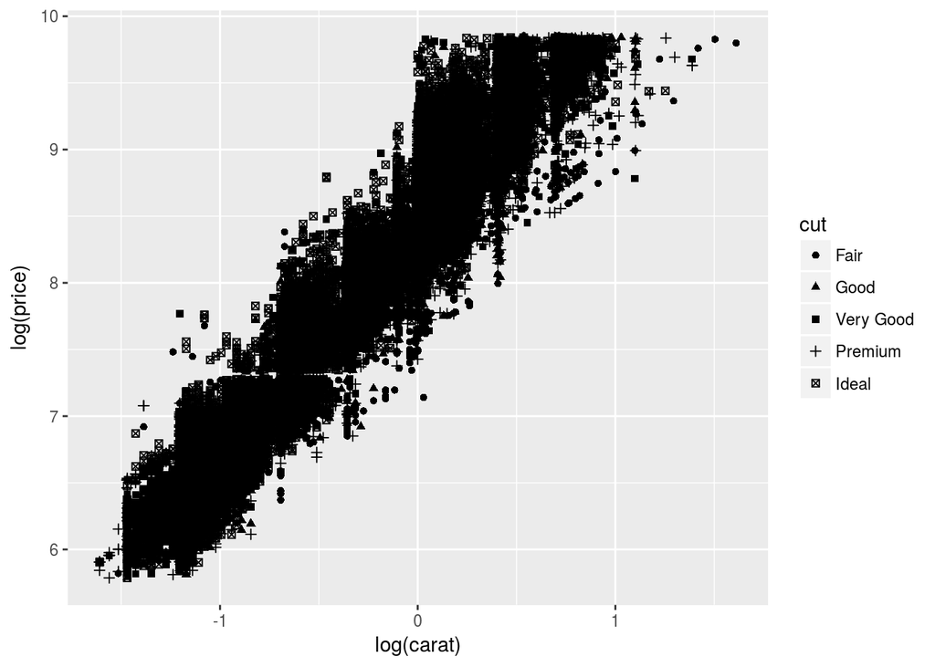

```r
#Grafico de dispersao quilates versus preco
#com formas diferentes para cada corte de diamante
qplot(log(carat), log(price), data = diamonds, shape = cut)
```

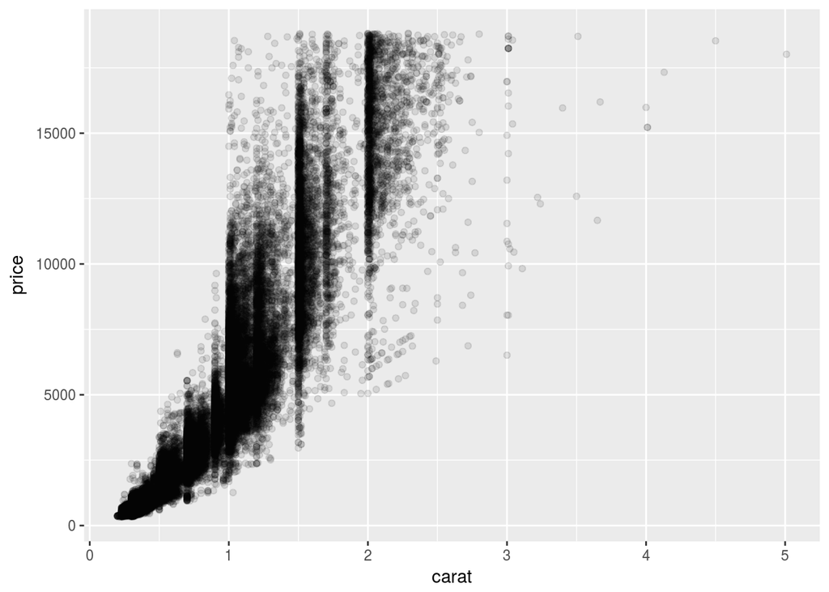

```r
#Grafico de dispersao quilates versus preco
#tornando os pontos transparentes

qplot(carat, price, data = diamonds, alpha = I(1/10))
```

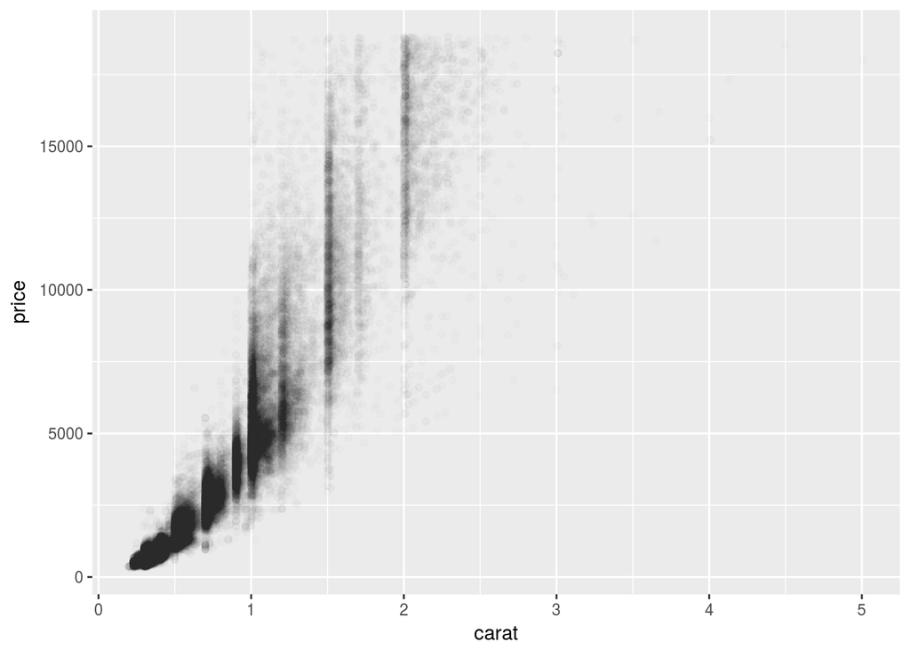

```r
qplot(carat, price, data = diamonds, alpha = I(1/100))
```

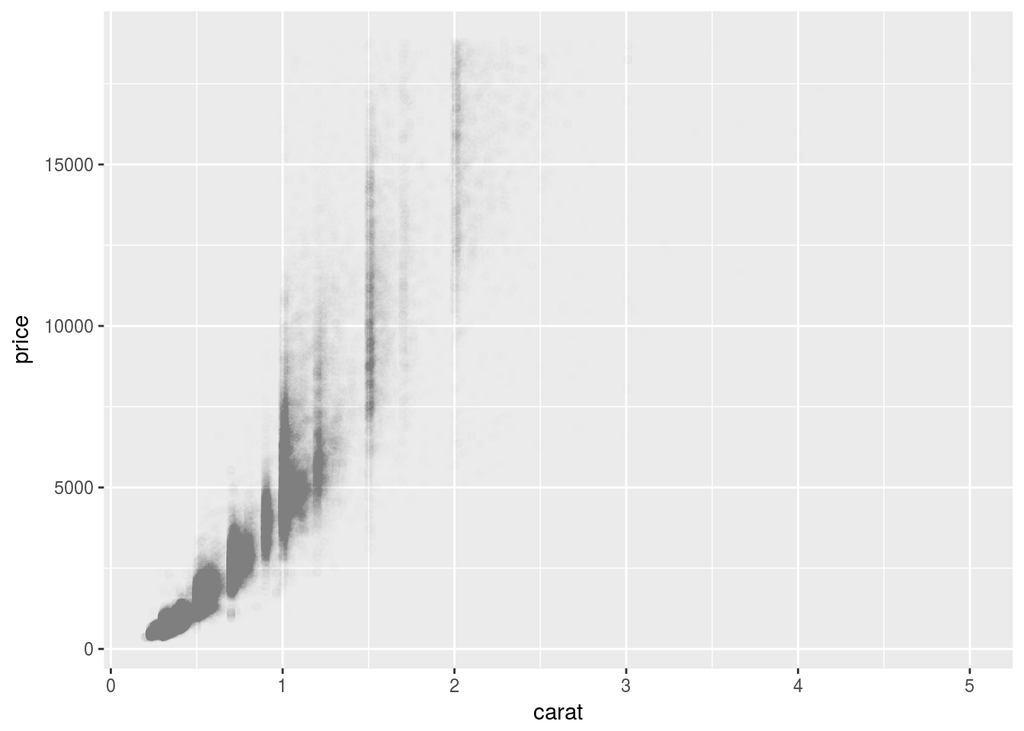

```r
qplot(carat, price, data = diamonds, alpha = I(1/200))
```

## Formas geometricas

1. geom = “point” produz pontos em um grafico de dispersão (default).
2. geom = “smooth” ajusta uma “curva alisada” aos dados.
3. geom = “boxplot” produz um box plot.
4. geom = “path” and geom = “line” produz lines entre os dados.
5. geom = “histogram” produz histogramas
6. geom = “density” ajusta um estimador de densidade nao parametrico.
7. geom = “bar” ajusta um grafico de barras.

### Ajustando uma reta aos dados

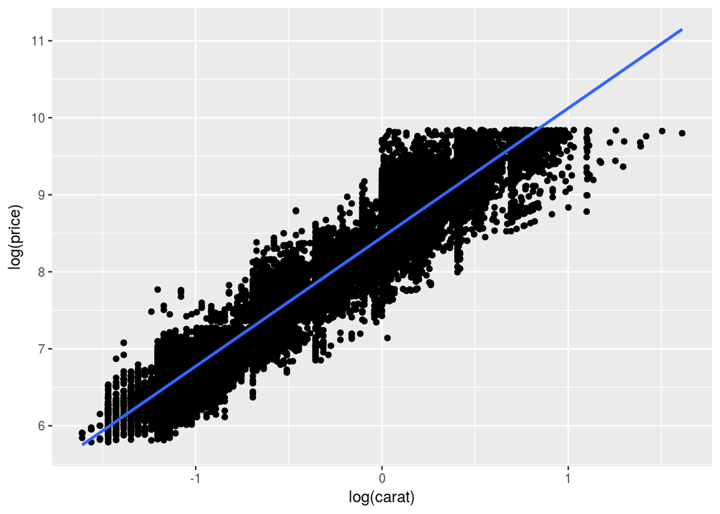

```r
#Grafico de dispersao quilates versus preco
#com uma reta de regressao ajustadas
qplot(log(carat), log(price), data = diamonds,
      geom = c("point", "smooth"), method="lm")
```

### Histograma

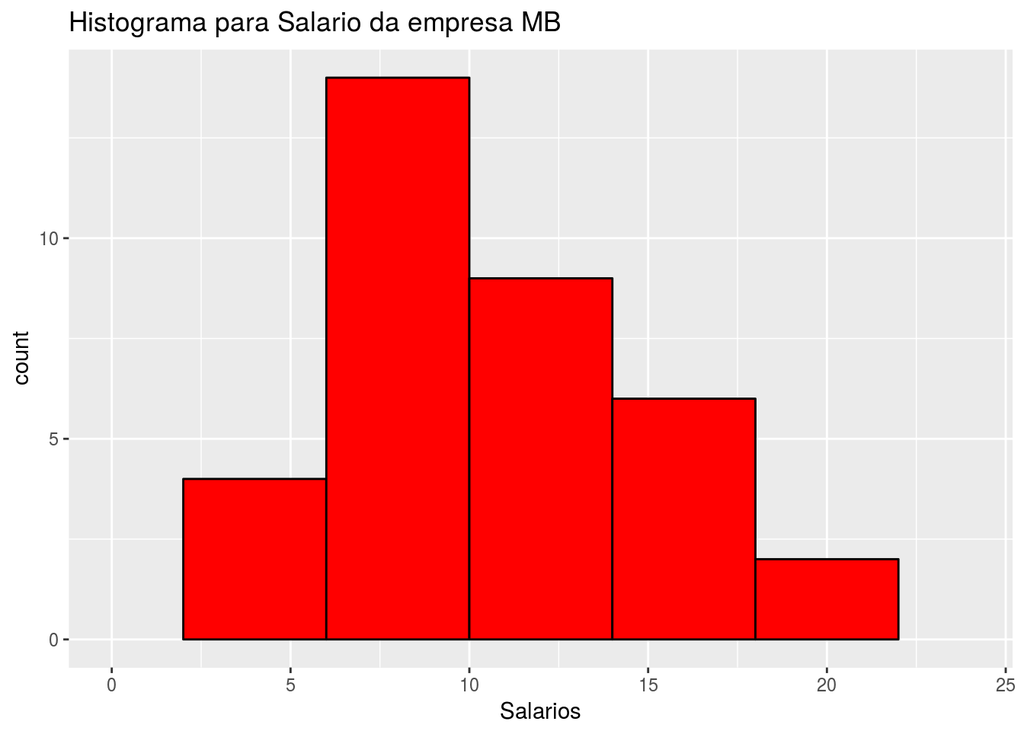

```r
#Ler os dados
tab21 = read.table("tabela2.1.txt", sep=";", dec=",", header = TRUE)

qplot(salario, data = tab21,  xlim=c(0,24),  binwidth = 4,
      main = "Histograma para Salario da empresa MB",
      xlab = "Salarios",
      fill=I("red"),
      col=I("black"))
```

###Grafico de barras

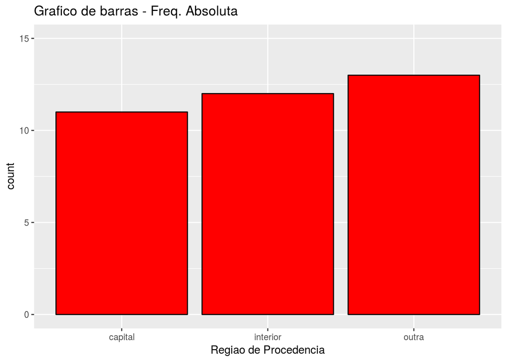

```r
#Frequencia Absoluta
qplot(reg_procedencia, data = tab21,   geom = c("bar"),
      main = "Grafico de barras - Freq. Absoluta",
      stat="identity",
      ylim = c(0,15),
      xlab = "Regiao de Procedencia",
      fill=I("red"),
      col=I("black"))
```